# Path analysis: NCP → Biogeochemistry → Coral physiology

# Path analysis 2 — pH temporal variability

The first path analysis uses the mean pH and DOC experienced by each tank. This section replaces both with **temporal variability** — the variance of daytime pH and DOC measurements across sampling dates within each tank. Variance captures a different dimension of the biogeochemical environment: not average conditions, but their consistency (or instability) over time.

Both variance terms are right-skewed and are log-transformed prior to z-scoring.

## Data preparation

```r
#tank_chem_var <- chem_reframe_DAY_clean |>
tank_chem_var <- clean_chem_fig |>
  group_by(TREATMENT, TANK_NUM) |>
  summarize(
    NEP_mean    = mean(NEP, na.rm = TRUE),
    log_pH_var  = log(var(pH,  na.rm = TRUE)),
    log_DOC_var = log(var(log(DOC), na.rm = TRUE)),
    .groups     = "drop"
  ) |>
  drop_na() |>
  mutate(TREATMENT = factor(TREATMENT, levels = treatment_levels))

tank_path_var <- tank_chem_var |>
  mutate(TANK_NUM = as.numeric(TANK_NUM)) |>
  left_join(
    tank_full |> select(TANK_NUM, log_chla, log_endo, log_biomass, mean_GP, mean_R),
    by = "TANK_NUM"
  ) |>
  mutate(across(c(NEP_mean, log_pH_var, log_DOC_var,
                  log_chla, log_endo, log_biomass, mean_GP, mean_R), scale)) |>
  drop_na()

cat("n tanks:", nrow(tank_path_var), "\n")
```

```
n tanks: 16
```

```r
cat("pH variance range:",  round(range(exp(tank_chem_var$log_pH_var),  na.rm = TRUE), 5), "\n")
```

```
pH variance range: 0.00068 0.01428
```

```r
cat("DOC variance range:", round(range(exp(tank_chem_var$log_DOC_var), na.rm = TRUE), 5), "(log-µmol/L)²\n")
```

```
DOC variance range: 0.04289 0.16523 (log-µmol/L)²
```

## Path model

The structure mirrors Path analysis 1, with `log_pH_var` replacing `pH_mean` and `log_DOC_var` replacing `DOC_mean`.

```r
var_path_model <- "
  # NCP → log(pH var) (c1) and log(DOC var) (d1)
  log_pH_var  ~ c1*NEP_mean
  log_DOC_var ~ d1*NEP_mean

  # log(pH var) (e1) and log(DOC var) (e2) → Chl-a
  log_chla ~ e1*log_pH_var + e2*log_DOC_var

  # Chl-a → downstream physiology (f1–f4)
  log_endo    ~ f1*log_chla
  mean_GP     ~ f2*log_chla
  mean_R      ~ f3*log_chla
  log_biomass ~ f4*log_chla

  # Residual covariance
  log_pH_var ~~ log_DOC_var

  # --- Indirect effects ---

  ind_NCP_pHvar_Chla      := c1 * e1
  ind_NCP_DOCvar_Chla     := d1 * e2
  ind_NCP_total_Chla      := (c1 * e1) + (d1 * e2)
  ind_pHvar_Chla_Endo     := e1 * f1
  ind_pHvar_Chla_GP       := e1 * f2
  ind_pHvar_Chla_R        := e1 * f3
  ind_pHvar_Chla_Biomass  := e1 * f4
  ind_DOCvar_Chla_Endo    := e2 * f1
  ind_DOCvar_Chla_GP      := e2 * f2
  ind_DOCvar_Chla_R       := e2 * f3
  ind_DOCvar_Chla_Biomass := e2 * f4
  ind_NCP_pHvar_Endo      := c1 * e1 * f1
  ind_NCP_pHvar_GP        := c1 * e1 * f2
  ind_NCP_pHvar_R         := c1 * e1 * f3
  ind_NCP_pHvar_Biomass   := c1 * e1 * f4
  ind_NCP_DOCvar_Endo     := d1 * e2 * f1
  ind_NCP_DOCvar_GP       := d1 * e2 * f2
  ind_NCP_DOCvar_R        := d1 * e2 * f3
  ind_NCP_DOCvar_Biomass  := d1 * e2 * f4
"

fit_var <- sem(var_path_model, data = as.data.frame(tank_path_var), estimator = "ML")
cat("Converged:", lavInspect(fit_var, "converged"), "\n")
```

```
Converged: TRUE
```

## Direct path coefficients

```r
var_path_coefs <- parameterEstimates(fit_var, standardized = TRUE) |>
  filter(op == "~") |>
  select(lhs, rhs, est, se, z, pvalue, std.all) |>
  mutate(
    lhs = recode(lhs,
      NEP_mean    = "NCP",
      log_pH_var  = "log(pH variance)",
      log_DOC_var = "log(DOC variance)",
      log_chla    = "Chl-a (log)",
      log_endo    = "Endosymbiont (log)",
      mean_GP     = "Gross photosynthesis",
      mean_R      = "Respiration",
      log_biomass = "Tissue biomass (log)"
    ),
    rhs = recode(rhs,
      NEP_mean    = "NCP",
      log_pH_var  = "log(pH variance)",
      log_DOC_var = "log(DOC variance)",
      log_chla    = "Chl-a (log)"
    ),
    across(where(is.numeric), ~ round(.x, 4))
  )

var_path_coefs |>
  kbl(
    caption = paste0(
      "Direct path coefficients from the pH-variance SEM (n = ",
      nrow(tank_path_var), " tanks). All variables z-scored. ",
      "Green = p < 0.05; yellow = 0.05 ≤ p < 0.10."
    ),
    col.names = c("Response", "Predictor", "Estimate", "SE", "z", "p", "Std. β")
  ) |>
  kable_styling(bootstrap_options = c("striped", "condensed"), full_width = FALSE) |>
  row_spec(which(var_path_coefs$pvalue < 0.05),  background = "#d4edda") |>
  row_spec(which(var_path_coefs$pvalue >= 0.05 & var_path_coefs$pvalue < 0.10),
           background = "#fff3cd")
```

Direct path coefficients from the pH-variance SEM (n = 16 tanks). All variables z-scored. Green = p < 0.05; yellow = 0.05 ≤ p < 0.10.

| Response | Predictor | Estimate | SE | z | p | Std. β |
| --- | --- | --- | --- | --- | --- | --- |
| log(pH variance) | NCP | 0.5561 | 0.2078 | 2.6761 | 0.0074 | 0.5561 |
| log(DOC variance) | NCP | -0.3313 | 0.2359 | -1.4046 | 0.1601 | -0.3313 |
| Chl-a (log) | log(pH variance) | 0.4613 | 0.2220 | 2.0782 | 0.0377 | 0.4613 |
| Chl-a (log) | log(DOC variance) | -0.0116 | 0.2220 | -0.0520 | 0.9585 | -0.0116 |
| Endosymbiont (log) | Chl-a (log) | 0.5217 | 0.2133 | 2.4461 | 0.0144 | 0.5217 |
| Gross photosynthesis | Chl-a (log) | 0.2629 | 0.2412 | 1.0899 | 0.2758 | 0.2629 |
| Respiration | Chl-a (log) | 0.6420 | 0.1917 | 3.3493 | 0.0008 | 0.6420 |
| Tissue biomass (log) | Chl-a (log) | 0.5103 | 0.2150 | 2.3734 | 0.0176 | 0.5103 |

## R² for endogenous variables

```r
lavInspect(fit_var, "r2") |>
  tibble::enframe(name = "Variable", value = "R2") |>
  mutate(
    Variable = recode(Variable,
      log_pH_var  = "log(pH variance)",
      log_DOC_var = "log(DOC variance)",
      log_chla    = "Chl-a (log)",
      log_endo    = "Endosymbiont (log)",
      mean_GP     = "Gross photosynthesis",
      mean_R      = "Respiration",
      log_biomass = "Tissue biomass (log)"
    ),
    R2 = round(R2, 3)
  ) |>
  kbl(
    caption = "R² for each endogenous variable in the pH-variance path model. Values represent the proportion of variance explained by all predictors in the model for each response variable.",
    col.names = c("Variable", "R²")
  ) |>
  kable_styling(bootstrap_options = c("striped", "condensed"), full_width = FALSE, position = "left")
```

R² for each endogenous variable in the pH-variance path model. Values represent the proportion of variance explained by all predictors in the model for each response variable.

| Variable | R² |
| --- | --- |
| log(pH variance) | 0.309 |
| log(DOC variance) | 0.110 |
| Chl-a (log) | 0.213 |
| Endosymbiont (log) | 0.272 |
| Gross photosynthesis | 0.069 |
| Respiration | 0.412 |
| Tissue biomass (log) | 0.260 |

## Path diagram

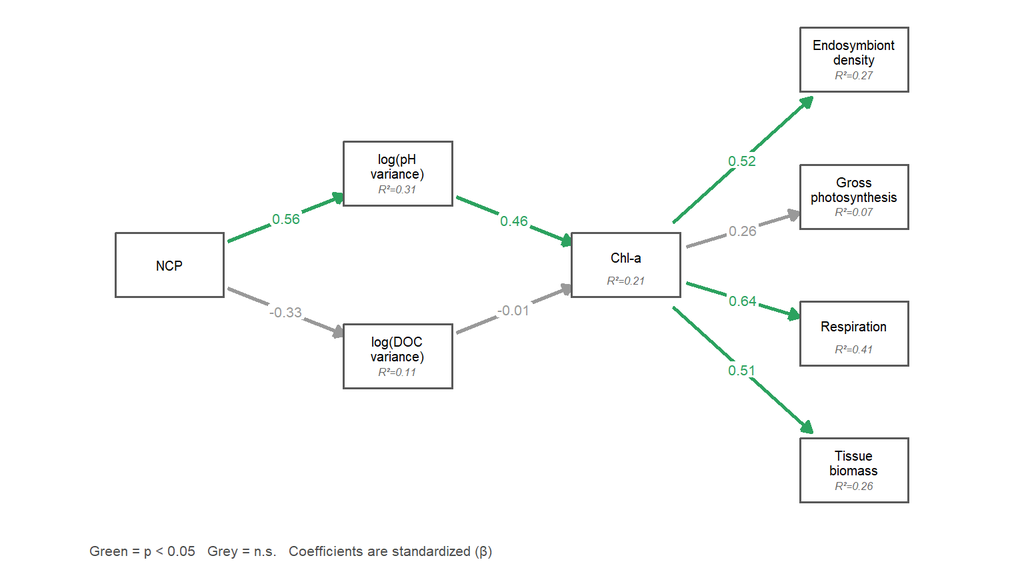

Path diagram for the variance model. Green = p < 0.05; grey = n.s. Numbers are standardized path coefficients (β). n = 16 tanks.

```r
var_nodes <- tibble(
  id    = c("NCP",  "pHvar",            "DOCvar",             "Chla",  "Endo",                 "GP",                   "R",           "Bio"),
  label = c("NCP",  "log(pH\nvariance)", "log(DOC\nvariance)", "Chl-a", "Endosymbiont\ndensity","Gross\nphotosynthesis", "Respiration", "Tissue\nbiomass"),
  x     = c(1,      3,                   3,                    5,        7,                       7,                       7,             7),
  y     = c(0,      0.8,                -0.8,                   0,        1.8,                     0.6,                    -0.6,          -1.8)
)

# Add R² from model to each endogenous node
r2_m2 <- lavInspect(fit_var, "r2")
var_nodes <- var_nodes |>
  left_join(
    tibble(id = c("pHvar",      "DOCvar",      "Chla",     "Endo",     "GP",       "R",      "Bio"),
           r2 = r2_m2[c("log_pH_var","log_DOC_var","log_chla","log_endo","mean_GP","mean_R","log_biomass")]),
    by = "id"
  ) |>
  mutate(
    r2_label = ifelse(!is.na(r2), sprintf("R\u00b2=%.2f", r2), NA_character_),
    label_y  = ifelse(!is.na(r2), y + 0.07, y)
  )

var_direct <- parameterEstimates(fit_var, standardized = TRUE) |>
  filter(op == "~") |>
  select(lhs, rhs, std.all, pvalue) |>
  mutate(
    lhs = recode(lhs, NEP_mean="NCP", log_pH_var="pHvar", log_DOC_var="DOCvar",
                 log_chla="Chla", log_endo="Endo", mean_GP="GP", mean_R="R", log_biomass="Bio"),
    rhs = recode(rhs, NEP_mean="NCP", log_pH_var="pHvar", log_DOC_var="DOCvar", log_chla="Chla"),
    sig = pvalue < 0.05
  )

var_edges <- tibble(
  from = c("NCP",   "NCP",   "pHvar", "DOCvar", "Chla", "Chla", "Chla", "Chla"),
  to   = c("pHvar", "DOCvar","Chla",  "Chla",   "Endo", "GP",   "R",    "Bio")
) |>
  left_join(var_direct |> select(lhs, rhs, std.all, sig),
            by = c("to" = "lhs", "from" = "rhs")) |>
  left_join(var_nodes |> select(id, x, y), by = c("from" = "id")) |>
  rename(x0 = x, y0 = y) |>
  left_join(var_nodes |> select(id, x, y), by = c("to" = "id")) |>
  rename(x1 = x, y1 = y)

var_edge_coords <- pmap_dfr(var_edges, function(from, to, std.all, sig, x0, y0, x1, y1) {
  dx <- x1-x0; dy <- y1-y0; d <- sqrt(dx^2+dy^2)
  tibble(from, to, coef=std.all, sig,
         xs=x0+dx/d*0.55, ys=y0+dy/d*0.55,
         xe=x1-dx/d*0.50, ye=y1-dy/d*0.50,
         mx=(x0+dx/d*0.55+x1-dx/d*0.50)/2,
         my=(y0+dy/d*0.55+y1-dy/d*0.50)/2)
})

ggplot() +
  geom_segment(
    data = var_edge_coords,
    aes(x = xs, y = ys, xend = xe, yend = ye, color = sig),
    linewidth = 0.9,
    arrow = arrow(length = unit(0.22, "cm"), type = "closed"),
    show.legend = FALSE
  ) +
  geom_label(
    data = var_edge_coords,
    aes(x = mx, y = my, label = sprintf("%.2f", coef), color = sig),
    size = 2.8, label.padding = unit(0.12, "lines"), label.size = 0,
    fill = "white", show.legend = FALSE
  ) +
  geom_tile(
    data = var_nodes,
    aes(x = x, y = y),
    width = 0.95, height = 0.56,
    fill = "white", color = "grey35", linewidth = 0.6
  ) +
  geom_text(
    data = var_nodes,
    aes(x = x, y = label_y, label = label),
    size = 2.7, lineheight = 0.9
  ) +
  geom_text(
    data = var_nodes |> filter(!is.na(r2_label)),
    aes(x = x, y = y - 0.13, label = r2_label),
    size = 2.1, color = "grey40", fontface = "italic"
  ) +
  scale_color_manual(values = c("TRUE" = "#2ca25f", "FALSE" = "grey60")) +
  annotate("text", x = 0.3, y = -2.5,
           label = "Green = p < 0.05   Grey = n.s.   Coefficients are standardized (\u03b2)",
           hjust = 0, size = 2.8, color = "grey30") +
  coord_equal(xlim = c(0.3, 7.7), ylim = c(-2.6, 2.2), expand = FALSE) +
  theme_void() +
  theme(plot.margin = margin(8, 8, 8, 8))
```

## Indirect effects

```r
var_indirect <- parameterEstimates(fit_var, standardized = TRUE) |>
  filter(op == ":=") |>
  select(label, est, se, z, pvalue, std.all) |>
  mutate(
    Pathway = recode(label,
      ind_NCP_pHvar_Chla      = "NCP → log(pH var.) → Chl-a",
      ind_NCP_DOCvar_Chla     = "NCP → log(DOC var.) → Chl-a",
      ind_NCP_total_Chla      = "NCP → [log(pH var.) + log(DOC var.)] → Chl-a  (total)",
      ind_pHvar_Chla_Endo     = "log(pH var.) → Chl-a → Endosymbiont",
      ind_pHvar_Chla_GP       = "log(pH var.) → Chl-a → Gross photosynthesis",
      ind_pHvar_Chla_R        = "log(pH var.) → Chl-a → Respiration",
      ind_pHvar_Chla_Biomass  = "log(pH var.) → Chl-a → Tissue biomass",
      ind_DOCvar_Chla_Endo    = "log(DOC var.) → Chl-a → Endosymbiont",
      ind_DOCvar_Chla_GP      = "log(DOC var.) → Chl-a → Gross photosynthesis",
      ind_DOCvar_Chla_R       = "log(DOC var.) → Chl-a → Respiration",
      ind_DOCvar_Chla_Biomass = "log(DOC var.) → Chl-a → Tissue biomass",
      ind_NCP_pHvar_Endo      = "NCP → log(pH var.) → Chl-a → Endosymbiont",
      ind_NCP_pHvar_GP        = "NCP → log(pH var.) → Chl-a → Gross photosynthesis",
      ind_NCP_pHvar_R         = "NCP → log(pH var.) → Chl-a → Respiration",
      ind_NCP_pHvar_Biomass   = "NCP → log(pH var.) → Chl-a → Tissue biomass",
      ind_NCP_DOCvar_Endo     = "NCP → log(DOC var.) → Chl-a → Endosymbiont",
      ind_NCP_DOCvar_GP       = "NCP → log(DOC var.) → Chl-a → Gross photosynthesis",
      ind_NCP_DOCvar_R        = "NCP → log(DOC var.) → Chl-a → Respiration",
      ind_NCP_DOCvar_Biomass  = "NCP → log(DOC var.) → Chl-a → Tissue biomass"
    ),
    across(where(is.numeric), ~ round(.x, 4)),
    Chain = case_when(
      grepl("^NCP → \\[", Pathway)                  ~ "NCP → Chl-a (total)",
      grepl("^NCP → log\\(pH.*Chla$", Pathway)      ~ "NCP → Chl-a (total)",
      grepl("^NCP → log\\(DOC.*Chla$", Pathway)     ~ "NCP → Chl-a (total)",
      grepl("^NCP → log\\(pH.*→ Chl-a →", Pathway) ~ "NCP → log(pH var.) → Chl-a → downstream",
      grepl("^NCP → log\\(DOC.*→ Chl-a →", Pathway)~ "NCP → log(DOC var.) → Chl-a → downstream",
      grepl("^log\\(pH", Pathway)                   ~ "log(pH var.) → Chl-a → downstream",
      grepl("^log\\(DOC", Pathway)                  ~ "log(DOC var.) → Chl-a → downstream",
      TRUE                                          ~ "Other"
    )
  ) |>
  arrange(Chain, desc(abs(est)))

var_indirect |>
  select(Chain, Pathway, est, se, z, pvalue, std.all) |>
  kbl(
    caption = "Indirect effects from the pH-variance SEM. Green = p < 0.05; yellow = 0.05 ≤ p < 0.10.",
    col.names = c("Chain group", "Pathway", "Estimate", "SE", "z", "p", "Std. β")
  ) |>
  kable_styling(bootstrap_options = c("striped", "condensed"), full_width = FALSE) |>
  collapse_rows(columns = 1, valign = "top") |>
  row_spec(which(var_indirect$pvalue < 0.05),  background = "#d4edda") |>
  row_spec(which(var_indirect$pvalue >= 0.05 & var_indirect$pvalue < 0.10),
           background = "#fff3cd")
```

Indirect effects from the pH-variance SEM. Green = p < 0.05; yellow = 0.05 ≤ p < 0.10.

| Chain group | Pathway | Estimate | SE | z | p | Std. β |
| --- | --- | --- | --- | --- | --- | --- |
| NCP → Chl-a (total) | NCP → [log(pH var.) + log(DOC var.)] → Chl-a (total) | 0.2604 | 0.1742 | 1.4946 | 0.1350 | 0.2604 |
| NCP → log(DOC var.) → Chl-a → downstream | NCP → log(DOC var.) → Chl-a → Respiration | 0.0025 | 0.0473 | 0.0520 | 0.9585 | 0.0025 |
|  | NCP → log(DOC var.) → Chl-a → Endosymbiont | 0.0020 | 0.0384 | 0.0520 | 0.9585 | 0.0020 |
|  | NCP → log(DOC var.) → Chl-a → Tissue biomass | 0.0020 | 0.0376 | 0.0520 | 0.9585 | 0.0020 |
|  | NCP → log(DOC var.) → Chl-a → Gross photosynthesis | 0.0010 | 0.0194 | 0.0519 | 0.9586 | 0.0010 |
| NCP → log(pH var.) → Chl-a → downstream | NCP → log(pH var.) → Chl-a → Respiration | 0.1647 | 0.1117 | 1.4739 | 0.1405 | 0.1647 |
|  | NCP → log(pH var.) → Chl-a → Endosymbiont | 0.1338 | 0.0982 | 1.3630 | 0.1729 | 0.1338 |
|  | NCP → log(pH var.) → Chl-a → Tissue biomass | 0.1309 | 0.0970 | 1.3500 | 0.1770 | 0.1309 |
|  | NCP → log(pH var.) → Chl-a → Gross photosynthesis | 0.0674 | 0.0743 | 0.9080 | 0.3639 | 0.0674 |
| Other | NCP → log(pH var.) → Chl-a | 0.2565 | 0.1563 | 1.6414 | 0.1007 | 0.2565 |
|  | NCP → log(DOC var.) → Chl-a | 0.0038 | 0.0736 | 0.0520 | 0.9585 | 0.0038 |
| log(DOC var.) → Chl-a → downstream | log(DOC var.) → Chl-a → Respiration | -0.0074 | 0.1425 | -0.0520 | 0.9585 | -0.0074 |
|  | log(DOC var.) → Chl-a → Endosymbiont | -0.0060 | 0.1158 | -0.0520 | 0.9585 | -0.0060 |
|  | log(DOC var.) → Chl-a → Tissue biomass | -0.0059 | 0.1133 | -0.0520 | 0.9585 | -0.0059 |
|  | log(DOC var.) → Chl-a → Gross photosynthesis | -0.0030 | 0.0584 | -0.0520 | 0.9585 | -0.0030 |
| log(pH var.) → Chl-a → downstream | log(pH var.) → Chl-a → Respiration | 0.2962 | 0.1677 | 1.7659 | 0.0774 | 0.2962 |
|  | log(pH var.) → Chl-a → Endosymbiont | 0.2407 | 0.1520 | 1.5838 | 0.1132 | 0.2407 |
|  | log(pH var.) → Chl-a → Tissue biomass | 0.2354 | 0.1506 | 1.5635 | 0.1179 | 0.2354 |
|  | log(pH var.) → Chl-a → Gross photosynthesis | 0.1213 | 0.1257 | 0.9652 | 0.3344 | 0.1213 |